# Quiz Part 6

#### `speeches_roh.csv`에는 노무현 전 대통령의 연설문 780개가 들어있습니다. `speeches_roh.csv`를 이용해 문제를 해결해 보세요.

Q1. `speeches_roh.csv`를 불러온 다음 연설문이 들어있는 `content`를 문장 기준으로 토큰화하세요.

Q2. 문장을 분석에 적합하게 전처리한 다음 명사를 추출하세요.

Q3. 연설문 내 중복 단어를 제거하고 빈도가 100회 이하인 단어를 추출하세요.

Q4. 추출한 단어에서 다음의 불용어를 제거하세요.

Q5. 연설문별 단어 빈도를 구한 다음 DTM을 만드세요.

Q6. 토픽 수를 2~20개로 바꿔가며 LDA 모델을 만든 다음 최적 토픽 수를 구하세요.

Q7. 토픽 수가 9개인 LDA 모델을 추출하세요.

Q8. LDA 모델의 beta를 이용해 각 토픽에 등장할 확률이 높은 상위 10개 단어를 추출한 다음 토픽별 주요 단어를 나타낸 막대 그래프를 만드세요.

Q9. LDA 모델의 gamma를 이용해 연설문 원문을 확률이 가장 높은 토픽으로 분류하세요.

Q10. 토픽별 문서 수를 출력하세요.

Q11. 문서가 가장 많은 토픽의 연설문을 gamma가 높은 순으로 출력하고 내용이 비슷한지 살펴보세요.

#### Q1. `speeches_roh.csv`를 불러온 다음 연설문이 들어있는 `content`를 문장 기준으로 토큰화하세요.

##### 연설문 불러오기

```r
library(readr)
speeches_raw <- read_csv("speeches_roh.csv")
```

##### 문장 기준 토큰화

```r
library(dplyr)
library(tidytext)
speeches <- speeches_raw %>%
  unnest_tokens(input = content,
                output = sentence,
                token = "sentences",
                drop = F)
```

> `KoNLP` 패키지의 함수는 토큰화할 텍스트가 너무 길면 오류가 발생합니다. 텍스트를 문장 기준으로 토큰화하고 나서 다시 명사 기준으로 토큰화하면 이런 문제를 피할 수 있습니다.
> - 노무현 전 대통령의 연설문 출처: bit.ly/easytext_35

#### Q2. 문장을 분석에 적합하게 전처리한 다음 명사를 추출하세요.

```r
# 전처리
library(stringr)
speeches <- speeches %>%
  mutate(sentence = str_replace_all(sentence, "[^가-힣]", " "),
         sentence = str_squish(sentence))
```

```r
# 명사 추출
library(tidytext)
library(KoNLP)
library(stringr)
nouns_speeches <- speeches %>%
  unnest_tokens(input = sentence,
                output = word,
                token = extractNoun,
                drop = F) %>%
  filter(str_count(word) > 1)
```

> 컴퓨터 성능에 따라 명사를 추출하는 데 시간이 오래 걸릴 수 있습니다.

#### Q3. 연설문 내 중복 단어를 제거하고 빈도가 100회 이하인 단어를 추출하세요.

##### 연설문 내 중복 단어 제거

```r
nouns_speeches <- nouns_speeches %>%
  group_by(id) %>%
  distinct(word, .keep_all = T) %>%
  ungroup()
```

##### 단어 빈도 100회 이하 단어 추출

```r
nouns_speeches <- nouns_speeches %>%
  add_count(word) %>%
  filter(n <= 100) %>%
  select(-n)
```

#### Q4. 추출한 단어에서 다음의 불용어를 제거하세요.

```r
stopword <- c("들이", "하다", "하게", "하면", "해서", "이번", "하네",
              "해요", "이것", "니들", "하기", "하지", "한거", "해주",
              "그것", "어디", "여기", "까지", "이거", "하신", "만큼")
```

##### 불용어 제거

```r
nouns_speeches <- nouns_speeches %>%
  filter(!word %in% stopword)
```

#### Q5. 연설문별 단어 빈도를 구한 다음 DTM을 만드세요.

##### 연설문별 단어 빈도 구하기

```r
count_word_doc <- nouns_speeches %>%
  count(id, word, sort = T)
```

##### DTM 만들기

```r
dtm_comment <- count_word_doc %>%
  cast_dtm(document = id, term = word, value = n)
```

#### Q6. 토픽 수를 2~20개로 바꿔가며 LDA 모델을 만든 다음 최적 토픽 수를 구하세요.

##### 토픽 수 바꿔가며 LDA 모델 만들기

```r
library(ldatuning)
models <- FindTopicsNumber(dtm = dtm_comment,
                           topics = 2:20,
                           return_models = T,
                           control = list(seed = 1234))
```

##### 최적 토픽 수 구하기

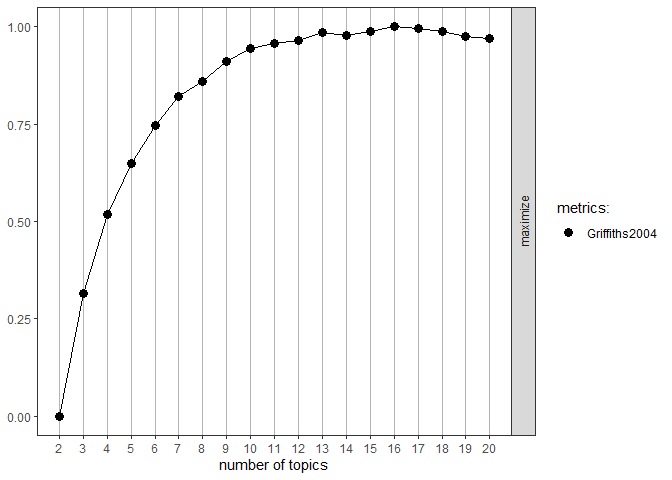

```r
FindTopicsNumber_plot(models)
```

#### Q7. 토픽 수가 9개인 LDA 모델을 추출하세요.

```r
lda_model <- models %>%
  filter (topics == 9) %>%
  pull(LDA_model) %>%
 .[[1]]
```

#### Q8. LDA 모델의 beta를 이용해 각 토픽에 등장할 확률이 높은 상위 10개 단어를 추출한 다음 토픽별 주요 단어를 나타낸 막대 그래프를 만드세요.

##### beta 추출

```r
term_topic <- tidy(lda_model, matrix = "beta")
```

##### 토픽별 beta 상위 단어 추출

```r
top_term_topic <- term_topic %>%
  group_by(topic) %>%
  slice_max(beta, n = 10)
```

##### 막대 그래프 만들기

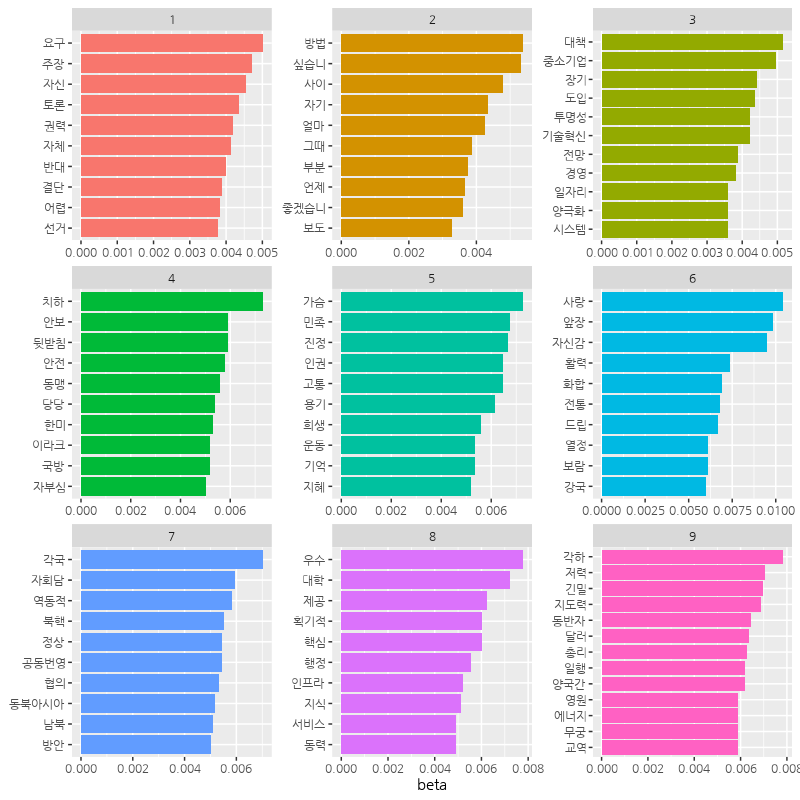

```r
library(ggplot2)
ggplot(top_term_topic,
       aes(x = reorder_within(term, beta, topic),
           y = beta,
           fill = factor(topic))) +
  geom_col(show.legend = F) +
  facet_wrap(~ topic, scales = "free", ncol = 3) +
  coord_flip () +
  scale_x_reordered() +
  labs(x = NULL)
```

#### Q9. LDA 모델의 gamma를 이용해 연설문 원문을 확률이 가장 높은 토픽으로 분류하세요.

##### gamma 추출

```r
doc_topic <- tidy(lda_model, matrix = "gamma")
```

##### 문서별로 확률이 가장 높은 토픽 추출

```r
doc_class <- doc_topic %>%
  group_by(document) %>%
  slice_max(gamma, n = 1)
```

##### 변수 타입 통일

```r
doc_class$document <- as.integer(doc_class$document)
```

##### 연설문 원문에 확률이 가장 높은 토픽 번호 부여

```r
speeches_topic <- speeches_raw %>%
  left_join(doc_class, by = c("id" = "document"))
```

#### Q10. 토픽별 문서 수를 출력하세요.

```r
speeches_topic %>%
  count(topic)
```

```
## # A tibble: 9 x 2
##   topic     n
##   <int> <int>
## 1     1    67
## 2     2    44
## 3     3    62
## 4     4    71
## 5     5    84
## 6     6   134
## 7     7    84
## 8     8   119
## 9     9   148
```

#### Q11. 문서가 가장 많은 토픽의 연설문을 gamma가 높은 순으로 출력하고 내용이 비슷한지 살펴보세요.

```r
speeches_topic %>%
  filter(topic == 9) %>%
  arrange(-gamma) %>%
  select(content)
```

```
## # A tibble: 148 x 1
##    content
##    <chr>
##  1 안녕하십니까, 이처럼 따뜻하게 맞아주셔서 감사합니다. 나지모프 대외경제청장과 김용구 중소기업중앙회장을 비롯한 양국 경제인 여러분께 감사드~
##  2 존경하는 룰라 대통령 각하 내외분, 그리고 귀빈 여러분, 오늘 저녁, BRICs 국가로 세계의 주목을 받고 있는 브라질의 귀한 손님을 모~
##  3 존경하는 압델아지즈 부테플리카 알제리 대통령 각하, 그리고 내외 귀빈 여러분, 나와 우리 일행을 따뜻하게 맞아주신 각하와 알제리 국민 여~
##  4 존경하는 압둘 라흐만 알 라쉬드 상의연합회 회장, 압둘 라흐만 알 안카리 경협위원장, 손경식 대한상의 회장, 김선동 경협위원장, 그리고 ~
##  5 존경하는 바세스쿠 대통령 각하, 그리고 귀빈 여러분, 각하와 일행 여러분의 방한을 진심으로 환영합니다. 먼저, 루마니아가 올해 수차례의 ~
##  6 존경하는 일함 알리예프 대통령 각하 내외분, 그리고 귀빈 여러분, 나와 우리 일행을 환대해 주신 각하 내외분께 감사드립니다. 대한민국 대~
##  7 존경하는 키르츠네르 대통령 각하 내외분, 그리고 귀빈 여러분, 우리 내외와 일행에 대한 환대에 감사드립니다. 부에노스 아이레스는 매우 아~
##  8 존경하는,카리모프, 대통령 각하 내외분, 그리고 귀빈 여러분, 각하 내외분과 일행 여러분을 진심으로 환영합니다. 오늘 이 자리가 양국의 ~
##  9 2005년 5월 10일 존경하는 카리모프 대통령 각하 내외분, 그리고 귀빈 여러분, 우리 내외와 일행을 환대해주시고, 성대한 만찬을 베풀~
## 10 존경하는 빌토르 바비욱 루마니아 상공회의소 회장, 그리고 손경식 대한상의 회장을 비롯한 양국 경제계 지도자 여러분, 안녕하십니까, 이렇게~
## # ... with 138 more rows
```